# GP_Star_Wars

GUIDED PROJECT FROM DATAQUEST Part of the course Data Cleaning

Last updated: January 4, 2018

```python
# Reading the data
import pandas as pd
import numpy

star_wars = pd.read_csv("star_wars.csv", encoding = "ISO-8859-1")
```

```python
# Displaying the first 10 rows

star_wars.head(10)
```

|  | RespondentID | Have you seen any of the 6 films in the Star Wars franchise? | Do you consider yourself to be a fan of the Star Wars film franchise? | Which of the following Star Wars films have you seen? Please select all that apply. | Unnamed: 4 | Unnamed: 5 | Unnamed: 6 | Unnamed: 7 | Unnamed: 8 | Please rank the Star Wars films in order of preference with 1 being your favorite film in the franchise and 6 being your least favorite film. | ... | Unnamed: 28 | Which character shot first? | Are you familiar with the Expanded Universe? | Do you consider yourself to be a fan of the Expanded Universe?æ | Do you consider yourself to be a fan of the Star Trek franchise? | Gender | Age | Household Income | Education | Location (Census Region) |
| --- | --- | --- | --- | --- | --- | --- | --- | --- | --- | --- | --- | --- | --- | --- | --- | --- | --- | --- | --- | --- | --- |
| 0 | NaN | Response | Response | Star Wars: Episode I The Phantom Menace | Star Wars: Episode II Attack of the Clones | Star Wars: Episode III Revenge of the Sith | Star Wars: Episode IV A New Hope | Star Wars: Episode V The Empire Strikes Back | Star Wars: Episode VI Return of the Jedi | Star Wars: Episode I The Phantom Menace | ... | Yoda | Response | Response | Response | Response | Response | Response | Response | Response | Response |
| 1 | 3.292880e+09 | Yes | Yes | Star Wars: Episode I The Phantom Menace | Star Wars: Episode II Attack of the Clones | Star Wars: Episode III Revenge of the Sith | Star Wars: Episode IV A New Hope | Star Wars: Episode V The Empire Strikes Back | Star Wars: Episode VI Return of the Jedi | 3 | ... | Very favorably | I don't understand this question | Yes | No | No | Male | 18-29 | NaN | High school degree | South Atlantic |
| 2 | 3.292880e+09 | No | NaN | NaN | NaN | NaN | NaN | NaN | NaN | NaN | ... | NaN | NaN | NaN | NaN | Yes | Male | 18-29 | $0 - $24,999 | Bachelor degree | West South Central |
| 3 | 3.292765e+09 | Yes | No | Star Wars: Episode I The Phantom Menace | Star Wars: Episode II Attack of the Clones | Star Wars: Episode III Revenge of the Sith | NaN | NaN | NaN | 1 | ... | Unfamiliar (N/A) | I don't understand this question | No | NaN | No | Male | 18-29 | $0 - $24,999 | High school degree | West North Central |
| 4 | 3.292763e+09 | Yes | Yes | Star Wars: Episode I The Phantom Menace | Star Wars: Episode II Attack of the Clones | Star Wars: Episode III Revenge of the Sith | Star Wars: Episode IV A New Hope | Star Wars: Episode V The Empire Strikes Back | Star Wars: Episode VI Return of the Jedi | 5 | ... | Very favorably | I don't understand this question | No | NaN | Yes | Male | 18-29 | $100,000 - $149,999 | Some college or Associate degree | West North Central |
| 5 | 3.292731e+09 | Yes | Yes | Star Wars: Episode I The Phantom Menace | Star Wars: Episode II Attack of the Clones | Star Wars: Episode III Revenge of the Sith | Star Wars: Episode IV A New Hope | Star Wars: Episode V The Empire Strikes Back | Star Wars: Episode VI Return of the Jedi | 5 | ... | Somewhat favorably | Greedo | Yes | No | No | Male | 18-29 | $100,000 - $149,999 | Some college or Associate degree | West North Central |
| 6 | 3.292719e+09 | Yes | Yes | Star Wars: Episode I The Phantom Menace | Star Wars: Episode II Attack of the Clones | Star Wars: Episode III Revenge of the Sith | Star Wars: Episode IV A New Hope | Star Wars: Episode V The Empire Strikes Back | Star Wars: Episode VI Return of the Jedi | 1 | ... | Very favorably | Han | Yes | No | Yes | Male | 18-29 | $25,000 - $49,999 | Bachelor degree | Middle Atlantic |
| 7 | 3.292685e+09 | Yes | Yes | Star Wars: Episode I The Phantom Menace | Star Wars: Episode II Attack of the Clones | Star Wars: Episode III Revenge of the Sith | Star Wars: Episode IV A New Hope | Star Wars: Episode V The Empire Strikes Back | Star Wars: Episode VI Return of the Jedi | 6 | ... | Very favorably | Han | Yes | No | No | Male | 18-29 | NaN | High school degree | East North Central |
| 8 | 3.292664e+09 | Yes | Yes | Star Wars: Episode I The Phantom Menace | Star Wars: Episode II Attack of the Clones | Star Wars: Episode III Revenge of the Sith | Star Wars: Episode IV A New Hope | Star Wars: Episode V The Empire Strikes Back | Star Wars: Episode VI Return of the Jedi | 4 | ... | Very favorably | Han | No | NaN | Yes | Male | 18-29 | NaN | High school degree | South Atlantic |
| 9 | 3.292654e+09 | Yes | Yes | Star Wars: Episode I The Phantom Menace | Star Wars: Episode II Attack of the Clones | Star Wars: Episode III Revenge of the Sith | Star Wars: Episode IV A New Hope | Star Wars: Episode V The Empire Strikes Back | Star Wars: Episode VI Return of the Jedi | 5 | ... | Somewhat favorably | Han | No | NaN | No | Male | 18-29 | $0 - $24,999 | Some college or Associate degree | South Atlantic |

10 rows × 38 columns

```python
# Displaying the column names

star_wars.columns
```

```
Index(['RespondentID',
       'Have you seen any of the 6 films in the Star Wars franchise?',
       'Do you consider yourself to be a fan of the Star Wars film franchise?',
       'Which of the following Star Wars films have you seen? Please select all that apply.',
       'Unnamed: 4', 'Unnamed: 5', 'Unnamed: 6', 'Unnamed: 7', 'Unnamed: 8',
       'Please rank the Star Wars films in order of preference with 1 being your favorite film in the franchise and 6 being your least favorite film.',
       'Unnamed: 10', 'Unnamed: 11', 'Unnamed: 12', 'Unnamed: 13',
       'Unnamed: 14',
       'Please state whether you view the following characters favorably, unfavorably, or are unfamiliar with him/her.',
       'Unnamed: 16', 'Unnamed: 17', 'Unnamed: 18', 'Unnamed: 19',
       'Unnamed: 20', 'Unnamed: 21', 'Unnamed: 22', 'Unnamed: 23',
       'Unnamed: 24', 'Unnamed: 25', 'Unnamed: 26', 'Unnamed: 27',
       'Unnamed: 28', 'Which character shot first?',
       'Are you familiar with the Expanded Universe?',
       'Do you consider yourself to be a fan of the Expanded Universe?ÂÃ¦',
       'Do you consider yourself to be a fan of the Star Trek franchise?',
       'Gender', 'Age', 'Household Income', 'Education',
       'Location (Census Region)'],
      dtype='object')
```

```python
# Generic function for the column names
import re

questions = star_wars.columns.tolist()

def get_col_index(regex, column_names = questions):
    for i, column in enumerate(column_names):
        if re.search(regex, column) is not None:
            col_index_list = i
            print(i)
    col_index = column_names[col_index_list]
    return col_index
```

```python
# Cleaning Step 1: Removing rows with NaN values for RespondentID

star_wars[pd.notnull(star_wars["RespondentID"])]
```

|  | RespondentID | Have you seen any of the 6 films in the Star Wars franchise? | Do you consider yourself to be a fan of the Star Wars film franchise? | Which of the following Star Wars films have you seen? Please select all that apply. | Unnamed: 4 | Unnamed: 5 | Unnamed: 6 | Unnamed: 7 | Unnamed: 8 | Please rank the Star Wars films in order of preference with 1 being your favorite film in the franchise and 6 being your least favorite film. | ... | Unnamed: 28 | Which character shot first? | Are you familiar with the Expanded Universe? | Do you consider yourself to be a fan of the Expanded Universe?æ | Do you consider yourself to be a fan of the Star Trek franchise? | Gender | Age | Household Income | Education | Location (Census Region) |
| --- | --- | --- | --- | --- | --- | --- | --- | --- | --- | --- | --- | --- | --- | --- | --- | --- | --- | --- | --- | --- | --- |
| 1 | 3.292880e+09 | Yes | Yes | Star Wars: Episode I The Phantom Menace | Star Wars: Episode II Attack of the Clones | Star Wars: Episode III Revenge of the Sith | Star Wars: Episode IV A New Hope | Star Wars: Episode V The Empire Strikes Back | Star Wars: Episode VI Return of the Jedi | 3 | ... | Very favorably | I don't understand this question | Yes | No | No | Male | 18-29 | NaN | High school degree | South Atlantic |
| 2 | 3.292880e+09 | No | NaN | NaN | NaN | NaN | NaN | NaN | NaN | NaN | ... | NaN | NaN | NaN | NaN | Yes | Male | 18-29 | $0 - $24,999 | Bachelor degree | West South Central |
| 3 | 3.292765e+09 | Yes | No | Star Wars: Episode I The Phantom Menace | Star Wars: Episode II Attack of the Clones | Star Wars: Episode III Revenge of the Sith | NaN | NaN | NaN | 1 | ... | Unfamiliar (N/A) | I don't understand this question | No | NaN | No | Male | 18-29 | $0 - $24,999 | High school degree | West North Central |
| 4 | 3.292763e+09 | Yes | Yes | Star Wars: Episode I The Phantom Menace | Star Wars: Episode II Attack of the Clones | Star Wars: Episode III Revenge of the Sith | Star Wars: Episode IV A New Hope | Star Wars: Episode V The Empire Strikes Back | Star Wars: Episode VI Return of the Jedi | 5 | ... | Very favorably | I don't understand this question | No | NaN | Yes | Male | 18-29 | $100,000 - $149,999 | Some college or Associate degree | West North Central |
| 5 | 3.292731e+09 | Yes | Yes | Star Wars: Episode I The Phantom Menace | Star Wars: Episode II Attack of the Clones | Star Wars: Episode III Revenge of the Sith | Star Wars: Episode IV A New Hope | Star Wars: Episode V The Empire Strikes Back | Star Wars: Episode VI Return of the Jedi | 5 | ... | Somewhat favorably | Greedo | Yes | No | No | Male | 18-29 | $100,000 - $149,999 | Some college or Associate degree | West North Central |
| 6 | 3.292719e+09 | Yes | Yes | Star Wars: Episode I The Phantom Menace | Star Wars: Episode II Attack of the Clones | Star Wars: Episode III Revenge of the Sith | Star Wars: Episode IV A New Hope | Star Wars: Episode V The Empire Strikes Back | Star Wars: Episode VI Return of the Jedi | 1 | ... | Very favorably | Han | Yes | No | Yes | Male | 18-29 | $25,000 - $49,999 | Bachelor degree | Middle Atlantic |
| 7 | 3.292685e+09 | Yes | Yes | Star Wars: Episode I The Phantom Menace | Star Wars: Episode II Attack of the Clones | Star Wars: Episode III Revenge of the Sith | Star Wars: Episode IV A New Hope | Star Wars: Episode V The Empire Strikes Back | Star Wars: Episode VI Return of the Jedi | 6 | ... | Very favorably | Han | Yes | No | No | Male | 18-29 | NaN | High school degree | East North Central |
| 8 | 3.292664e+09 | Yes | Yes | Star Wars: Episode I The Phantom Menace | Star Wars: Episode II Attack of the Clones | Star Wars: Episode III Revenge of the Sith | Star Wars: Episode IV A New Hope | Star Wars: Episode V The Empire Strikes Back | Star Wars: Episode VI Return of the Jedi | 4 | ... | Very favorably | Han | No | NaN | Yes | Male | 18-29 | NaN | High school degree | South Atlantic |
| 9 | 3.292654e+09 | Yes | Yes | Star Wars: Episode I The Phantom Menace | Star Wars: Episode II Attack of the Clones | Star Wars: Episode III Revenge of the Sith | Star Wars: Episode IV A New Hope | Star Wars: Episode V The Empire Strikes Back | Star Wars: Episode VI Return of the Jedi | 5 | ... | Somewhat favorably | Han | No | NaN | No | Male | 18-29 | $0 - $24,999 | Some college or Associate degree | South Atlantic |
| 10 | 3.292640e+09 | Yes | No | NaN | Star Wars: Episode II Attack of the Clones | NaN | NaN | NaN | NaN | 1 | ... | Very favorably | I don't understand this question | No | NaN | No | Male | 18-29 | $25,000 - $49,999 | Some college or Associate degree | Pacific |
| 11 | 3.292638e+09 | Yes | NaN | NaN | NaN | NaN | NaN | NaN | NaN | NaN | ... | NaN | NaN | NaN | NaN | NaN | NaN | NaN | NaN | NaN | NaN |
| 12 | 3.292635e+09 | No | NaN | NaN | NaN | NaN | NaN | NaN | NaN | NaN | ... | NaN | NaN | NaN | NaN | NaN | NaN | NaN | NaN | NaN | NaN |
| 13 | 3.292609e+09 | Yes | No | Star Wars: Episode I The Phantom Menace | Star Wars: Episode II Attack of the Clones | Star Wars: Episode III Revenge of the Sith | Star Wars: Episode IV A New Hope | Star Wars: Episode V The Empire Strikes Back | Star Wars: Episode VI Return of the Jedi | 3 | ... | Very favorably | Greedo | No | NaN | No | Male | 18-29 | $25,000 - $49,999 | Bachelor degree | South Atlantic |
| 14 | 3.292597e+09 | Yes | Yes | Star Wars: Episode I The Phantom Menace | Star Wars: Episode II Attack of the Clones | Star Wars: Episode III Revenge of the Sith | Star Wars: Episode IV A New Hope | Star Wars: Episode V The Empire Strikes Back | Star Wars: Episode VI Return of the Jedi | 4 | ... | Very favorably | I don't understand this question | No | NaN | No | Male | 30-44 | $50,000 - $99,999 | Graduate degree | Mountain |
| 15 | 3.292587e+09 | Yes | Yes | Star Wars: Episode I The Phantom Menace | Star Wars: Episode II Attack of the Clones | Star Wars: Episode III Revenge of the Sith | Star Wars: Episode IV A New Hope | Star Wars: Episode V The Empire Strikes Back | Star Wars: Episode VI Return of the Jedi | 4 | ... | Very favorably | Han | No | NaN | No | Male | 18-29 | NaN | High school degree | East North Central |
| 16 | 3.292583e+09 | Yes | Yes | Star Wars: Episode I The Phantom Menace | Star Wars: Episode II Attack of the Clones | Star Wars: Episode III Revenge of the Sith | Star Wars: Episode IV A New Hope | Star Wars: Episode V The Empire Strikes Back | Star Wars: Episode VI Return of the Jedi | 4 | ... | Somewhat favorably | Han | Yes | Yes | Yes | Male | 18-29 | $0 - $24,999 | Some college or Associate degree | West South Central |
| 17 | 3.292581e+09 | Yes | Yes | NaN | NaN | NaN | Star Wars: Episode IV A New Hope | NaN | NaN | 4 | ... | Very unfavorably | Han | Yes | Yes | No | Male | 18-29 | $50,000 - $99,999 | Bachelor degree | New England |
| 18 | 3.292573e+09 | Yes | Yes | Star Wars: Episode I The Phantom Menace | Star Wars: Episode II Attack of the Clones | Star Wars: Episode III Revenge of the Sith | NaN | NaN | Star Wars: Episode VI Return of the Jedi | 1 | ... | Very favorably | Greedo | No | NaN | No | Male | 18-29 | NaN | Some college or Associate degree | Middle Atlantic |
| 19 | 3.292565e+09 | Yes | Yes | Star Wars: Episode I The Phantom Menace | Star Wars: Episode II Attack of the Clones | Star Wars: Episode III Revenge of the Sith | Star Wars: Episode IV A New Hope | Star Wars: Episode V The Empire Strikes Back | Star Wars: Episode VI Return of the Jedi | 6 | ... | Very favorably | Han | No | NaN | No | Male | 18-29 | NaN | High school degree | South Atlantic |
| 20 | 3.292562e+09 | Yes | Yes | Star Wars: Episode I The Phantom Menace | Star Wars: Episode II Attack of the Clones | Star Wars: Episode III Revenge of the Sith | Star Wars: Episode IV A New Hope | Star Wars: Episode V The Empire Strikes Back | Star Wars: Episode VI Return of the Jedi | 6 | ... | Very favorably | Greedo | No | NaN | Yes | Male | 18-29 | $50,000 - $99,999 | Some college or Associate degree | West North Central |
| 21 | 3.292522e+09 | Yes | Yes | Star Wars: Episode I The Phantom Menace | Star Wars: Episode II Attack of the Clones | Star Wars: Episode III Revenge of the Sith | Star Wars: Episode IV A New Hope | Star Wars: Episode V The Empire Strikes Back | Star Wars: Episode VI Return of the Jedi | 6 | ... | Very favorably | Han | No | NaN | No | Male | 18-29 | NaN | Some college or Associate degree | Pacific |
| 22 | 3.292521e+09 | Yes | No | Star Wars: Episode I The Phantom Menace | Star Wars: Episode II Attack of the Clones | Star Wars: Episode III Revenge of the Sith | Star Wars: Episode IV A New Hope | Star Wars: Episode V The Empire Strikes Back | NaN | 3 | ... | Neither favorably nor unfavorably (neutral) | I don't understand this question | No | NaN | No | Male | 18-29 | NaN | Bachelor degree | Pacific |
| 23 | 3.292512e+09 | Yes | Yes | Star Wars: Episode I The Phantom Menace | Star Wars: Episode II Attack of the Clones | Star Wars: Episode III Revenge of the Sith | Star Wars: Episode IV A New Hope | Star Wars: Episode V The Empire Strikes Back | Star Wars: Episode VI Return of the Jedi | 6 | ... | Very favorably | Greedo | Yes | Yes | Yes | Male | 18-29 | $50,000 - $99,999 | Bachelor degree | South Atlantic |
| 24 | 3.292483e+09 | Yes | Yes | Star Wars: Episode I The Phantom Menace | Star Wars: Episode II Attack of the Clones | Star Wars: Episode III Revenge of the Sith | Star Wars: Episode IV A New Hope | Star Wars: Episode V The Empire Strikes Back | Star Wars: Episode VI Return of the Jedi | 6 | ... | Very favorably | Han | No | NaN | No | Male | 18-29 | $0 - $24,999 | Bachelor degree | Pacific |
| 25 | 3.292465e+09 | Yes | Yes | Star Wars: Episode I The Phantom Menace | Star Wars: Episode II Attack of the Clones | Star Wars: Episode III Revenge of the Sith | Star Wars: Episode IV A New Hope | Star Wars: Episode V The Empire Strikes Back | Star Wars: Episode VI Return of the Jedi | 1 | ... | Very favorably | Han | No | NaN | No | Male | 18-29 | NaN | NaN | East North Central |
| 26 | 3.292448e+09 | No | NaN | NaN | NaN | NaN | NaN | NaN | NaN | NaN | ... | NaN | NaN | NaN | NaN | Yes | Male | 18-29 | $0 - $24,999 | High school degree | East South Central |
| 27 | 3.292420e+09 | Yes | Yes | Star Wars: Episode I The Phantom Menace | Star Wars: Episode II Attack of the Clones | Star Wars: Episode III Revenge of the Sith | Star Wars: Episode IV A New Hope | Star Wars: Episode V The Empire Strikes Back | Star Wars: Episode VI Return of the Jedi | 4 | ... | Very favorably | Greedo | Yes | No | No | Male | 18-29 | $100,000 - $149,999 | Some college or Associate degree | South Atlantic |
| 28 | 3.292384e+09 | Yes | Yes | Star Wars: Episode I The Phantom Menace | Star Wars: Episode II Attack of the Clones | Star Wars: Episode III Revenge of the Sith | Star Wars: Episode IV A New Hope | Star Wars: Episode V The Empire Strikes Back | Star Wars: Episode VI Return of the Jedi | 6 | ... | Very favorably | Greedo | No | NaN | No | Male | 18-29 | NaN | Some college or Associate degree | Middle Atlantic |
| 29 | 3.292380e+09 | Yes | Yes | Star Wars: Episode I The Phantom Menace | Star Wars: Episode II Attack of the Clones | Star Wars: Episode III Revenge of the Sith | Star Wars: Episode IV A New Hope | Star Wars: Episode V The Empire Strikes Back | Star Wars: Episode VI Return of the Jedi | 6 | ... | Very favorably | Han | Yes | No | No | Male | 18-29 | NaN | Some college or Associate degree | Middle Atlantic |
| 30 | 3.292377e+09 | Yes | Yes | Star Wars: Episode I The Phantom Menace | Star Wars: Episode II Attack of the Clones | Star Wars: Episode III Revenge of the Sith | Star Wars: Episode IV A New Hope | Star Wars: Episode V The Empire Strikes Back | Star Wars: Episode VI Return of the Jedi | 4 | ... | Very favorably | Han | Yes | Yes | Yes | Male | 18-29 | $150,000+ | Some college or Associate degree | East North Central |
| ... | ... | ... | ... | ... | ... | ... | ... | ... | ... | ... | ... | ... | ... | ... | ... | ... | ... | ... | ... | ... | ... |
| 1157 | 3.288426e+09 | Yes | No | Star Wars: Episode I The Phantom Menace | Star Wars: Episode II Attack of the Clones | Star Wars: Episode III Revenge of the Sith | Star Wars: Episode IV A New Hope | Star Wars: Episode V The Empire Strikes Back | Star Wars: Episode VI Return of the Jedi | 3 | ... | Very favorably | I don't understand this question | No | NaN | No | Female | 30-44 | $50,000 - $99,999 | Graduate degree | Middle Atlantic |
| 1158 | 3.288423e+09 | No | NaN | NaN | NaN | NaN | NaN | NaN | NaN | NaN | ... | NaN | NaN | NaN | NaN | No | Male | 45-60 | $100,000 - $149,999 | Graduate degree | Middle Atlantic |
| 1159 | 3.288423e+09 | Yes | No | NaN | NaN | NaN | NaN | Star Wars: Episode V The Empire Strikes Back | Star Wars: Episode VI Return of the Jedi | 2 | ... | Very favorably | I don't understand this question | No | NaN | No | Female | 45-60 | $0 - $24,999 | Bachelor degree | Pacific |
| 1160 | 3.288422e+09 | No | NaN | NaN | NaN | NaN | NaN | NaN | NaN | NaN | ... | NaN | NaN | NaN | NaN | No | Female | > 60 | $0 - $24,999 | Some college or Associate degree | West South Central |
| 1161 | 3.288421e+09 | Yes | No | Star Wars: Episode I The Phantom Menace | NaN | Star Wars: Episode III Revenge of the Sith | NaN | NaN | Star Wars: Episode VI Return of the Jedi | 3 | ... | Very favorably | I don't understand this question | No | NaN | No | Female | 18-29 | $25,000 - $49,999 | Some college or Associate degree | Pacific |
| 1162 | 3.288418e+09 | Yes | No | Star Wars: Episode I The Phantom Menace | Star Wars: Episode II Attack of the Clones | Star Wars: Episode III Revenge of the Sith | NaN | Star Wars: Episode V The Empire Strikes Back | Star Wars: Episode VI Return of the Jedi | 3 | ... | Neither favorably nor unfavorably (neutral) | Greedo | No | NaN | No | NaN | NaN | NaN | NaN | NaN |
| 1163 | 3.288418e+09 | Yes | Yes | Star Wars: Episode I The Phantom Menace | NaN | NaN | Star Wars: Episode IV A New Hope | Star Wars: Episode V The Empire Strikes Back | Star Wars: Episode VI Return of the Jedi | 4 | ... | Very favorably | I don't understand this question | No | NaN | No | Female | 18-29 | $25,000 - $49,999 | Graduate degree | South Atlantic |
| 1164 | 3.288417e+09 | Yes | No | NaN | NaN | NaN | Star Wars: Episode IV A New Hope | Star Wars: Episode V The Empire Strikes Back | Star Wars: Episode VI Return of the Jedi | 5 | ... | Very favorably | Han | Yes | No | No | Female | > 60 | NaN | Bachelor degree | New England |
| 1165 | 3.288415e+09 | Yes | No | Star Wars: Episode I The Phantom Menace | Star Wars: Episode II Attack of the Clones | Star Wars: Episode III Revenge of the Sith | NaN | Star Wars: Episode V The Empire Strikes Back | Star Wars: Episode VI Return of the Jedi | 5 | ... | Neither favorably nor unfavorably (neutral) | Han | No | NaN | No | Male | 45-60 | $100,000 - $149,999 | Graduate degree | Middle Atlantic |
| 1166 | 3.288414e+09 | Yes | Yes | Star Wars: Episode I The Phantom Menace | Star Wars: Episode II Attack of the Clones | Star Wars: Episode III Revenge of the Sith | Star Wars: Episode IV A New Hope | Star Wars: Episode V The Empire Strikes Back | Star Wars: Episode VI Return of the Jedi | 5 | ... | Very favorably | Greedo | No | NaN | Yes | Female | 30-44 | $50,000 - $99,999 | Bachelor degree | Mountain |
| 1167 | 3.288413e+09 | Yes | Yes | Star Wars: Episode I The Phantom Menace | Star Wars: Episode II Attack of the Clones | Star Wars: Episode III Revenge of the Sith | Star Wars: Episode IV A New Hope | Star Wars: Episode V The Empire Strikes Back | Star Wars: Episode VI Return of the Jedi | 6 | ... | Very favorably | I don't understand this question | No | NaN | No | Female | 18-29 | $150,000+ | Some college or Associate degree | South Atlantic |
| 1168 | 3.288410e+09 | Yes | No | Star Wars: Episode I The Phantom Menace | NaN | NaN | NaN | Star Wars: Episode V The Empire Strikes Back | Star Wars: Episode VI Return of the Jedi | 3 | ... | Very favorably | Greedo | Yes | No | No | Female | 30-44 | NaN | Graduate degree | East North Central |
| 1169 | 3.288410e+09 | No | NaN | NaN | NaN | NaN | NaN | NaN | NaN | NaN | ... | NaN | NaN | NaN | NaN | No | Female | 30-44 | $150,000+ | Graduate degree | East North Central |
| 1170 | 3.288409e+09 | Yes | Yes | Star Wars: Episode I The Phantom Menace | NaN | NaN | Star Wars: Episode IV A New Hope | Star Wars: Episode V The Empire Strikes Back | Star Wars: Episode VI Return of the Jedi | 4 | ... | Very favorably | Han | No | NaN | Yes | Male | 45-60 | $25,000 - $49,999 | Bachelor degree | South Atlantic |
| 1171 | 3.288403e+09 | No | NaN | NaN | NaN | NaN | NaN | NaN | NaN | NaN | ... | NaN | NaN | NaN | NaN | No | Female | 45-60 | NaN | Graduate degree | East North Central |
| 1172 | 3.288403e+09 | Yes | Yes | Star Wars: Episode I The Phantom Menace | Star Wars: Episode II Attack of the Clones | Star Wars: Episode III Revenge of the Sith | Star Wars: Episode IV A New Hope | Star Wars: Episode V The Empire Strikes Back | Star Wars: Episode VI Return of the Jedi | 6 | ... | Somewhat unfavorably | Han | Yes | Yes | Yes | Female | > 60 | $25,000 - $49,999 | Bachelor degree | Mountain |
| 1173 | 3.288403e+09 | Yes | Yes | NaN | NaN | NaN | Star Wars: Episode IV A New Hope | Star Wars: Episode V The Empire Strikes Back | Star Wars: Episode VI Return of the Jedi | 2 | ... | Somewhat favorably | Greedo | Yes | No | Yes | Female | > 60 | NaN | High school degree | Pacific |
| 1174 | 3.288403e+09 | Yes | Yes | Star Wars: Episode I The Phantom Menace | Star Wars: Episode II Attack of the Clones | Star Wars: Episode III Revenge of the Sith | Star Wars: Episode IV A New Hope | Star Wars: Episode V The Empire Strikes Back | Star Wars: Episode VI Return of the Jedi | 5 | ... | Very favorably | Han | No | NaN | Yes | Female | 30-44 | NaN | Bachelor degree | Middle Atlantic |
| 1175 | 3.288402e+09 | Yes | No | Star Wars: Episode I The Phantom Menace | Star Wars: Episode II Attack of the Clones | Star Wars: Episode III Revenge of the Sith | NaN | NaN | NaN | 1 | ... | Very favorably | I don't understand this question | No | NaN | Yes | Female | > 60 | NaN | Some college or Associate degree | West North Central |
| 1176 | 3.288401e+09 | Yes | Yes | Star Wars: Episode I The Phantom Menace | Star Wars: Episode II Attack of the Clones | Star Wars: Episode III Revenge of the Sith | Star Wars: Episode IV A New Hope | Star Wars: Episode V The Empire Strikes Back | Star Wars: Episode VI Return of the Jedi | 1 | ... | Somewhat favorably | Han | Yes | No | Yes | Female | 45-60 | $50,000 - $99,999 | Graduate degree | West South Central |
| 1177 | 3.288398e+09 | Yes | No | Star Wars: Episode I The Phantom Menace | Star Wars: Episode II Attack of the Clones | NaN | NaN | NaN | NaN | 2 | ... | Neither favorably nor unfavorably (neutral) | I don't understand this question | No | NaN | No | Female | 45-60 | $0 - $24,999 | High school degree | Middle Atlantic |
| 1178 | 3.288396e+09 | Yes | No | Star Wars: Episode I The Phantom Menace | Star Wars: Episode II Attack of the Clones | Star Wars: Episode III Revenge of the Sith | NaN | Star Wars: Episode V The Empire Strikes Back | Star Wars: Episode VI Return of the Jedi | 1 | ... | Very favorably | I don't understand this question | No | NaN | Yes | Male | > 60 | $50,000 - $99,999 | Some college or Associate degree | Pacific |
| 1179 | 3.288395e+09 | No | NaN | NaN | NaN | NaN | NaN | NaN | NaN | NaN | ... | NaN | NaN | NaN | NaN | No | Female | 18-29 | NaN | Less than high school degree | West North Central |
| 1180 | 3.288392e+09 | Yes | Yes | NaN | NaN | NaN | NaN | Star Wars: Episode V The Empire Strikes Back | Star Wars: Episode VI Return of the Jedi | 3 | ... | Very favorably | Han | No | NaN | Yes | Female | 45-60 | $0 - $24,999 | Some college or Associate degree | West North Central |
| 1181 | 3.288390e+09 | Yes | Yes | Star Wars: Episode I The Phantom Menace | Star Wars: Episode II Attack of the Clones | Star Wars: Episode III Revenge of the Sith | Star Wars: Episode IV A New Hope | Star Wars: Episode V The Empire Strikes Back | Star Wars: Episode VI Return of the Jedi | 3 | ... | Very favorably | Han | No | NaN | No | Female | 45-60 | $0 - $24,999 | Some college or Associate degree | Pacific |
| 1182 | 3.288389e+09 | Yes | Yes | Star Wars: Episode I The Phantom Menace | Star Wars: Episode II Attack of the Clones | Star Wars: Episode III Revenge of the Sith | Star Wars: Episode IV A New Hope | Star Wars: Episode V The Empire Strikes Back | Star Wars: Episode VI Return of the Jedi | 5 | ... | Very favorably | Han | No | NaN | Yes | Female | 18-29 | $0 - $24,999 | Some college or Associate degree | East North Central |
| 1183 | 3.288379e+09 | Yes | Yes | Star Wars: Episode I The Phantom Menace | Star Wars: Episode II Attack of the Clones | Star Wars: Episode III Revenge of the Sith | Star Wars: Episode IV A New Hope | Star Wars: Episode V The Empire Strikes Back | Star Wars: Episode VI Return of the Jedi | 4 | ... | Very favorably | I don't understand this question | No | NaN | Yes | Female | 30-44 | $50,000 - $99,999 | Bachelor degree | Mountain |
| 1184 | 3.288375e+09 | No | NaN | NaN | NaN | NaN | NaN | NaN | NaN | NaN | ... | NaN | NaN | NaN | NaN | No | Female | 30-44 | $50,000 - $99,999 | Bachelor degree | Middle Atlantic |
| 1185 | 3.288373e+09 | Yes | Yes | Star Wars: Episode I The Phantom Menace | Star Wars: Episode II Attack of the Clones | Star Wars: Episode III Revenge of the Sith | Star Wars: Episode IV A New Hope | Star Wars: Episode V The Empire Strikes Back | Star Wars: Episode VI Return of the Jedi | 4 | ... | Very favorably | Han | No | NaN | Yes | Female | 45-60 | $100,000 - $149,999 | Some college or Associate degree | East North Central |
| 1186 | 3.288373e+09 | Yes | No | Star Wars: Episode I The Phantom Menace | Star Wars: Episode II Attack of the Clones | NaN | NaN | Star Wars: Episode V The Empire Strikes Back | Star Wars: Episode VI Return of the Jedi | 6 | ... | Very unfavorably | I don't understand this question | No | NaN | No | Female | > 60 | $50,000 - $99,999 | Graduate degree | Pacific |

1186 rows × 38 columns

```python
# Cleaning Step 2A
# Converting Yes and No answers to True and False respectively.

# Creating a dictionary for the replacement
yes_no = {"Yes": True, "No": False}

# For the column: Have you seen any of the 6 films in the Star Wars franchise?

column_title = get_col_index("6 films")
star_wars[column_title] = star_wars[column_title].map(yes_no)

star_wars.head()
```

```
1
```

|  | RespondentID | Have you seen any of the 6 films in the Star Wars franchise? | Do you consider yourself to be a fan of the Star Wars film franchise? | Which of the following Star Wars films have you seen? Please select all that apply. | Unnamed: 4 | Unnamed: 5 | Unnamed: 6 | Unnamed: 7 | Unnamed: 8 | Please rank the Star Wars films in order of preference with 1 being your favorite film in the franchise and 6 being your least favorite film. | ... | Unnamed: 28 | Which character shot first? | Are you familiar with the Expanded Universe? | Do you consider yourself to be a fan of the Expanded Universe?æ | Do you consider yourself to be a fan of the Star Trek franchise? | Gender | Age | Household Income | Education | Location (Census Region) |
| --- | --- | --- | --- | --- | --- | --- | --- | --- | --- | --- | --- | --- | --- | --- | --- | --- | --- | --- | --- | --- | --- |
| 0 | NaN | NaN | Response | Star Wars: Episode I The Phantom Menace | Star Wars: Episode II Attack of the Clones | Star Wars: Episode III Revenge of the Sith | Star Wars: Episode IV A New Hope | Star Wars: Episode V The Empire Strikes Back | Star Wars: Episode VI Return of the Jedi | Star Wars: Episode I The Phantom Menace | ... | Yoda | Response | Response | Response | Response | Response | Response | Response | Response | Response |
| 1 | 3.292880e+09 | True | Yes | Star Wars: Episode I The Phantom Menace | Star Wars: Episode II Attack of the Clones | Star Wars: Episode III Revenge of the Sith | Star Wars: Episode IV A New Hope | Star Wars: Episode V The Empire Strikes Back | Star Wars: Episode VI Return of the Jedi | 3 | ... | Very favorably | I don't understand this question | Yes | No | No | Male | 18-29 | NaN | High school degree | South Atlantic |
| 2 | 3.292880e+09 | False | NaN | NaN | NaN | NaN | NaN | NaN | NaN | NaN | ... | NaN | NaN | NaN | NaN | Yes | Male | 18-29 | $0 - $24,999 | Bachelor degree | West South Central |
| 3 | 3.292765e+09 | True | No | Star Wars: Episode I The Phantom Menace | Star Wars: Episode II Attack of the Clones | Star Wars: Episode III Revenge of the Sith | NaN | NaN | NaN | 1 | ... | Unfamiliar (N/A) | I don't understand this question | No | NaN | No | Male | 18-29 | $0 - $24,999 | High school degree | West North Central |
| 4 | 3.292763e+09 | True | Yes | Star Wars: Episode I The Phantom Menace | Star Wars: Episode II Attack of the Clones | Star Wars: Episode III Revenge of the Sith | Star Wars: Episode IV A New Hope | Star Wars: Episode V The Empire Strikes Back | Star Wars: Episode VI Return of the Jedi | 5 | ... | Very favorably | I don't understand this question | No | NaN | Yes | Male | 18-29 | $100,000 - $149,999 | Some college or Associate degree | West North Central |

5 rows × 38 columns

```python
# Cleaning Step 2B
# For the column Do you consider yourself to be a fan of the Star Wars film franchise?

column_title = get_col_index("fan of the Star Wars")
star_wars[column_title] = star_wars[column_title].map(yes_no)

star_wars.head()
```

```
2
```

|  | RespondentID | Have you seen any of the 6 films in the Star Wars franchise? | Do you consider yourself to be a fan of the Star Wars film franchise? | Which of the following Star Wars films have you seen? Please select all that apply. | Unnamed: 4 | Unnamed: 5 | Unnamed: 6 | Unnamed: 7 | Unnamed: 8 | Please rank the Star Wars films in order of preference with 1 being your favorite film in the franchise and 6 being your least favorite film. | ... | Unnamed: 28 | Which character shot first? | Are you familiar with the Expanded Universe? | Do you consider yourself to be a fan of the Expanded Universe?æ | Do you consider yourself to be a fan of the Star Trek franchise? | Gender | Age | Household Income | Education | Location (Census Region) |
| --- | --- | --- | --- | --- | --- | --- | --- | --- | --- | --- | --- | --- | --- | --- | --- | --- | --- | --- | --- | --- | --- |
| 0 | NaN | NaN | NaN | Star Wars: Episode I The Phantom Menace | Star Wars: Episode II Attack of the Clones | Star Wars: Episode III Revenge of the Sith | Star Wars: Episode IV A New Hope | Star Wars: Episode V The Empire Strikes Back | Star Wars: Episode VI Return of the Jedi | Star Wars: Episode I The Phantom Menace | ... | Yoda | Response | Response | Response | Response | Response | Response | Response | Response | Response |
| 1 | 3.292880e+09 | True | True | Star Wars: Episode I The Phantom Menace | Star Wars: Episode II Attack of the Clones | Star Wars: Episode III Revenge of the Sith | Star Wars: Episode IV A New Hope | Star Wars: Episode V The Empire Strikes Back | Star Wars: Episode VI Return of the Jedi | 3 | ... | Very favorably | I don't understand this question | Yes | No | No | Male | 18-29 | NaN | High school degree | South Atlantic |
| 2 | 3.292880e+09 | False | NaN | NaN | NaN | NaN | NaN | NaN | NaN | NaN | ... | NaN | NaN | NaN | NaN | Yes | Male | 18-29 | $0 - $24,999 | Bachelor degree | West South Central |
| 3 | 3.292765e+09 | True | False | Star Wars: Episode I The Phantom Menace | Star Wars: Episode II Attack of the Clones | Star Wars: Episode III Revenge of the Sith | NaN | NaN | NaN | 1 | ... | Unfamiliar (N/A) | I don't understand this question | No | NaN | No | Male | 18-29 | $0 - $24,999 | High school degree | West North Central |
| 4 | 3.292763e+09 | True | True | Star Wars: Episode I The Phantom Menace | Star Wars: Episode II Attack of the Clones | Star Wars: Episode III Revenge of the Sith | Star Wars: Episode IV A New Hope | Star Wars: Episode V The Empire Strikes Back | Star Wars: Episode VI Return of the Jedi | 5 | ... | Very favorably | I don't understand this question | No | NaN | Yes | Male | 18-29 | $100,000 - $149,999 | Some college or Associate degree | West North Central |

5 rows × 38 columns

```python
# Cleaning Step 3 - Part 1

# Creating the dictionary for replacement
movie_dictionary = {}

for i in range(3, 9):
    temp_list = star_wars[star_wars.columns[i]].unique().tolist()
    movie_dictionary[temp_list[0]] = True
movie_dictionary["NaN"] = False

# Replacing responses with True or False

for i in range(3, 9):
    star_wars[star_wars.columns[i]] = star_wars[star_wars.columns[i]].map(movie_dictionary)

star_wars.head()
```

|  | RespondentID | Have you seen any of the 6 films in the Star Wars franchise? | Do you consider yourself to be a fan of the Star Wars film franchise? | Which of the following Star Wars films have you seen? Please select all that apply. | Unnamed: 4 | Unnamed: 5 | Unnamed: 6 | Unnamed: 7 | Unnamed: 8 | Please rank the Star Wars films in order of preference with 1 being your favorite film in the franchise and 6 being your least favorite film. | ... | Unnamed: 28 | Which character shot first? | Are you familiar with the Expanded Universe? | Do you consider yourself to be a fan of the Expanded Universe?æ | Do you consider yourself to be a fan of the Star Trek franchise? | Gender | Age | Household Income | Education | Location (Census Region) |
| --- | --- | --- | --- | --- | --- | --- | --- | --- | --- | --- | --- | --- | --- | --- | --- | --- | --- | --- | --- | --- | --- |
| 0 | NaN | NaN | NaN | True | True | True | True | True | True | Star Wars: Episode I The Phantom Menace | ... | Yoda | Response | Response | Response | Response | Response | Response | Response | Response | Response |
| 1 | 3.292880e+09 | True | True | True | True | True | True | True | True | 3 | ... | Very favorably | I don't understand this question | Yes | No | No | Male | 18-29 | NaN | High school degree | South Atlantic |
| 2 | 3.292880e+09 | False | NaN | NaN | NaN | NaN | NaN | NaN | NaN | NaN | ... | NaN | NaN | NaN | NaN | Yes | Male | 18-29 | $0 - $24,999 | Bachelor degree | West South Central |
| 3 | 3.292765e+09 | True | False | True | True | True | NaN | NaN | NaN | 1 | ... | Unfamiliar (N/A) | I don't understand this question | No | NaN | No | Male | 18-29 | $0 - $24,999 | High school degree | West North Central |
| 4 | 3.292763e+09 | True | True | True | True | True | True | True | True | 5 | ... | Very favorably | I don't understand this question | No | NaN | Yes | Male | 18-29 | $100,000 - $149,999 | Some college or Associate degree | West North Central |

5 rows × 38 columns

```python
# Cleaning Step 3 - Part 2
# Renaming the column names

new_names_seen = ["seen_1", "seen_2", "seen_3", "seen_4", "seen_5", "seen_6"]

for i in range(3, 9):
    star_wars = star_wars.rename(columns = {star_wars.columns[i]: new_names_seen[i-3]})

star_wars.head()
```

|  | RespondentID | Have you seen any of the 6 films in the Star Wars franchise? | Do you consider yourself to be a fan of the Star Wars film franchise? | seen_1 | seen_2 | seen_3 | seen_4 | seen_5 | seen_6 | Please rank the Star Wars films in order of preference with 1 being your favorite film in the franchise and 6 being your least favorite film. | ... | Unnamed: 28 | Which character shot first? | Are you familiar with the Expanded Universe? | Do you consider yourself to be a fan of the Expanded Universe?æ | Do you consider yourself to be a fan of the Star Trek franchise? | Gender | Age | Household Income | Education | Location (Census Region) |
| --- | --- | --- | --- | --- | --- | --- | --- | --- | --- | --- | --- | --- | --- | --- | --- | --- | --- | --- | --- | --- | --- |
| 0 | NaN | NaN | NaN | True | True | True | True | True | True | Star Wars: Episode I The Phantom Menace | ... | Yoda | Response | Response | Response | Response | Response | Response | Response | Response | Response |
| 1 | 3.292880e+09 | True | True | True | True | True | True | True | True | 3 | ... | Very favorably | I don't understand this question | Yes | No | No | Male | 18-29 | NaN | High school degree | South Atlantic |
| 2 | 3.292880e+09 | False | NaN | NaN | NaN | NaN | NaN | NaN | NaN | NaN | ... | NaN | NaN | NaN | NaN | Yes | Male | 18-29 | $0 - $24,999 | Bachelor degree | West South Central |
| 3 | 3.292765e+09 | True | False | True | True | True | NaN | NaN | NaN | 1 | ... | Unfamiliar (N/A) | I don't understand this question | No | NaN | No | Male | 18-29 | $0 - $24,999 | High school degree | West North Central |
| 4 | 3.292763e+09 | True | True | True | True | True | True | True | True | 5 | ... | Very favorably | I don't understand this question | No | NaN | Yes | Male | 18-29 | $100,000 - $149,999 | Some college or Associate degree | West North Central |

5 rows × 38 columns

```python
# Cleaning Step 4 - Part 1
# Converting to float

def convert_to_float(df):
    try:
        converted = float(df)
    except Exception as exc:
        converted = None
    return converted

for i in range (9, 15):
     star_wars[star_wars.columns[i]] = star_wars[star_wars.columns[i]].apply(convert_to_float)

star_wars.head()
```

|  | RespondentID | Have you seen any of the 6 films in the Star Wars franchise? | Do you consider yourself to be a fan of the Star Wars film franchise? | seen_1 | seen_2 | seen_3 | seen_4 | seen_5 | seen_6 | Please rank the Star Wars films in order of preference with 1 being your favorite film in the franchise and 6 being your least favorite film. | ... | Unnamed: 28 | Which character shot first? | Are you familiar with the Expanded Universe? | Do you consider yourself to be a fan of the Expanded Universe?æ | Do you consider yourself to be a fan of the Star Trek franchise? | Gender | Age | Household Income | Education | Location (Census Region) |
| --- | --- | --- | --- | --- | --- | --- | --- | --- | --- | --- | --- | --- | --- | --- | --- | --- | --- | --- | --- | --- | --- |
| 0 | NaN | NaN | NaN | True | True | True | True | True | True | NaN | ... | Yoda | Response | Response | Response | Response | Response | Response | Response | Response | Response |
| 1 | 3.292880e+09 | True | True | True | True | True | True | True | True | 3.0 | ... | Very favorably | I don't understand this question | Yes | No | No | Male | 18-29 | NaN | High school degree | South Atlantic |
| 2 | 3.292880e+09 | False | NaN | NaN | NaN | NaN | NaN | NaN | NaN | NaN | ... | NaN | NaN | NaN | NaN | Yes | Male | 18-29 | $0 - $24,999 | Bachelor degree | West South Central |
| 3 | 3.292765e+09 | True | False | True | True | True | NaN | NaN | NaN | 1.0 | ... | Unfamiliar (N/A) | I don't understand this question | No | NaN | No | Male | 18-29 | $0 - $24,999 | High school degree | West North Central |
| 4 | 3.292763e+09 | True | True | True | True | True | True | True | True | 5.0 | ... | Very favorably | I don't understand this question | No | NaN | Yes | Male | 18-29 | $100,000 - $149,999 | Some college or Associate degree | West North Central |

5 rows × 38 columns

```python
# Cleaning Step 4 - Part 2
# Renaming columns

new_names_ranking = ["ranking_1", "ranking_2", "ranking_3", "ranking_4", "ranking_5", "ranking_6"]

for i in range(9, 15):
    star_wars = star_wars.rename(columns = {star_wars.columns[i]:new_names_ranking[i-9]})

star_wars.head()
```

|  | RespondentID | Have you seen any of the 6 films in the Star Wars franchise? | Do you consider yourself to be a fan of the Star Wars film franchise? | seen_1 | seen_2 | seen_3 | seen_4 | seen_5 | seen_6 | ranking_1 | ... | Unnamed: 28 | Which character shot first? | Are you familiar with the Expanded Universe? | Do you consider yourself to be a fan of the Expanded Universe?æ | Do you consider yourself to be a fan of the Star Trek franchise? | Gender | Age | Household Income | Education | Location (Census Region) |
| --- | --- | --- | --- | --- | --- | --- | --- | --- | --- | --- | --- | --- | --- | --- | --- | --- | --- | --- | --- | --- | --- |
| 0 | NaN | NaN | NaN | True | True | True | True | True | True | NaN | ... | Yoda | Response | Response | Response | Response | Response | Response | Response | Response | Response |
| 1 | 3.292880e+09 | True | True | True | True | True | True | True | True | 3.0 | ... | Very favorably | I don't understand this question | Yes | No | No | Male | 18-29 | NaN | High school degree | South Atlantic |
| 2 | 3.292880e+09 | False | NaN | NaN | NaN | NaN | NaN | NaN | NaN | NaN | ... | NaN | NaN | NaN | NaN | Yes | Male | 18-29 | $0 - $24,999 | Bachelor degree | West South Central |
| 3 | 3.292765e+09 | True | False | True | True | True | NaN | NaN | NaN | 1.0 | ... | Unfamiliar (N/A) | I don't understand this question | No | NaN | No | Male | 18-29 | $0 - $24,999 | High school degree | West North Central |
| 4 | 3.292763e+09 | True | True | True | True | True | True | True | True | 5.0 | ... | Very favorably | I don't understand this question | No | NaN | Yes | Male | 18-29 | $100,000 - $149,999 | Some college or Associate degree | West North Central |

5 rows × 38 columns

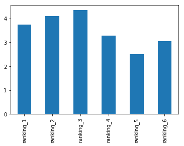

```python
# Analysis - Finding the highest ranked movie

%matplotlib inline
import matplotlib.pyplot as plt

ranking_mean = star_wars[star_wars.columns[9:15]].mean()

ranking_mean.plot(kind = "bar")
```

The following columns represent ranking of respondents for the following movies:

ranking_1: Respondent rank for Star Wars: Episode I The Phantom Menace

ranking_2: Respondent rank for Star Wars: Episode II Attack of the Clones

ranking_3: Respondent rank for Star Wars: Episode III Revenge of the Sith

ranking_4: Respondent rank for Star Wars: Episode IV A New Hope

ranking_5: Respondent rank for Star Wars: Episode V: The Empire Strikes Back

ranking_6: Respondent rank for Star Wars: Episode VI Return of the Jedi

Each respondent was asked to rank the movies from 1 to 6 with 1 being the most favorable while 6 being the least favorable. To get a general respresentation of respondent ranking for each column, the mean for each column was calculated. A bar plot of the mean was also displayed, showing ranking_5 to have the smallest ranking of all. This indicates that more people favored The Empire Strikes Back among the 6 movie franchises.

It can also be noticed that the older franchises (ranking_4, ranking_5, and ranking_6) are more popular than the newer franchises (ranking_1, ranking_2, and ranking_3). And among the newer franchises, there seems to be a trend of a newer franchise being less popular than its predecessor.

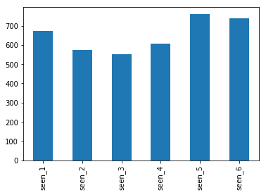

```python
# Analysis 2 - Counting the number of people who have seen each
# franchise

seen_sum = star_wars[star_wars.columns[3:9]].sum()

seen_sum.plot(kind = "bar")
```

The following columns represent the number of people who have seen each respective Star Wars franchise:

seen_1: Respondents who have seen Episode I

seen_2: Respondents who have seen Episode II

seen_3: Respondents who have seen Episode III

seen_4: Respondents who have seen Episode IV

seen_5: Respondents who have seen Episode V

seen_6: Respondents who have seen Episode VI

The bar plots show that Episode V (Empire Strikes Back) has the highest number of viewers followed by Episode VI (Return of the Jedi). The newer franchises exhibit a seemingly downward trend of viewers with Episode I having the highest number of viewers while Episode III having the lowest.

Relating it to ranking, it is not surprising to see that the newer franchises that were ranked lower will have lesser viewers than their predecessors. Given that a newer franchise is not so enjoyable, a viewer will tend to skip the next part of the franchise, considering his/her last experience with its predecessor.

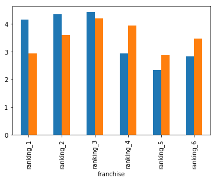

```python
# Analysis 3A: Part 1 - Dividing the data into star wars fans
# and not star wars fans

# Dataframe for star wars fans responses
star_wars_fan = star_wars[star_wars[star_wars.columns[2]] == True]

# Dataframe for non star wars fans responses
star_wars_not_fan = star_wars[star_wars[star_wars.columns[2]] != True]

# Finding the mean ranking per film
mean_ranking_sw_fan = star_wars_fan[star_wars_fan.columns[9:15]].mean().tolist()
mean_ranking_sw_notfan = star_wars_not_fan[star_wars_not_fan.columns[9:15]].mean().tolist()

# Preparation for Grouped Bar Plots
new_column_names = ["franchise", "fan_response", "non_fan_response"]
bundled_data_list = [new_names_ranking, mean_ranking_sw_fan, mean_ranking_sw_notfan]

# Creating a general function

def df_for_group_plot(data_list, column_names):
    temp_dictionary = {}
    for i, title in enumerate(column_names):
        temp_dictionary[title] = data_list[i]
    new_df = pd.DataFrame(temp_dictionary)
    return (new_df)

fan_ranking_dataframe = df_for_group_plot(bundled_data_list, new_column_names)

fan_ranking_dataframe.plot(x = "franchise", kind = "bar", legend = False)
```

Ranking by Star Wars fans is in blue, while ranking by non-Star-Wars-fans is in orange.

Fan or no fan of the franchise, the best ranked film is still The Empire Strikes Back.

Noticeably, fans of the franchise ranked the older films better than the newer ones, where A New Hope and Return of the Jedi almost ranking the same. For non-fans of the franchise, Phantom Menace was noticeably ranked better than Revenge of the Sith.

For both fans and non-fans, the downward trend in preference for the newer franchise is still evident in the plots given above.

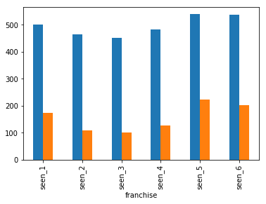

```python
# Analysis 3A - Part 2

# Finding the total number of viewers per franchise
total_viewers_sw_fan = star_wars_fan[star_wars_fan.columns[3:9]].sum().tolist()
total_viewers_sw_notfan = star_wars_not_fan[star_wars_not_fan.columns[3:9]].sum().tolist()

# Preparation for Grouped Bar Plots
bundled_data_list = [new_names_seen, total_viewers_sw_fan, total_viewers_sw_notfan]

viewer_dataframe = df_for_group_plot(bundled_data_list, new_column_names)
viewer_dataframe.plot(x = "franchise", kind = "bar", legend = False)
```

Blue bars represent the number of viewers per franchise for star wars fans while orange bars represent the number of viewers per franchise for non-star-wars-fans.

Not surprisingly, there is a significant higher number of viewers for star wars fans versus those who are not fans.

But the number of viewers for Empire Strikes Back (seen_5) are still greater for all franchises, whether the viewers are fans or not fans of Star Wars. The least watched of all the franchises is still Revenge of the Sith.

```
32
```

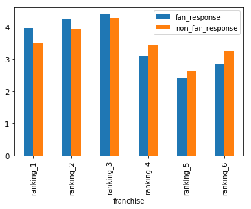

```python
# Analysis 3B - Dividing the data into Star Trek Fans and
# not Star Trek Fans

trekkie = get_col_index("Star Trek")

trekkie_fans = star_wars[star_wars[trekkie] == "Yes"]
trekkie_notfans = star_wars[star_wars[trekkie] != "Yes"]

# Part 1
# Finding the mean ranking per film
mean_ranking_trekkie_fans = trekkie_fans[trekkie_fans.columns[9:15]].mean().tolist()
mean_ranking_trekkie_notfans = trekkie_notfans[trekkie_notfans.columns[9:15]].mean().tolist()

# Preparation for grouped bar plots
bundled_data_list = [new_names_ranking, mean_ranking_trekkie_fans, mean_ranking_trekkie_notfans]

fan_ranking_dataframe = df_for_group_plot(bundled_data_list, new_column_names)
fan_ranking_dataframe.plot(x = "franchise", kind = "bar")
```

Ranking based on star trek fandom reflects the same general results as ranking based on star wars fandom. The parallelism may be due to the general observation that most star wars fans are also star trek fans.

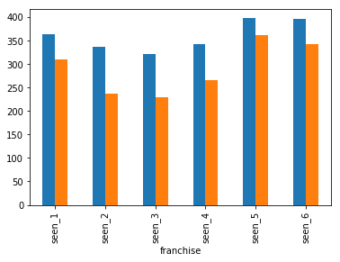

```python
# Analysis 3B - Part 2

# Finding the total number of viewers per franchise
total_viewers_trekkie_fan = trekkie_fans[trekkie_fans.columns[3:9]].sum().tolist()
total_viewers_trekkie_notfan = trekkie_notfans[trekkie_notfans.columns[3:9]].sum().tolist()

# Preparation for grouped bar plots
bundled_data_list = [new_names_seen, total_viewers_trekkie_fan, total_viewers_trekkie_notfan]

viewer_dataframe = df_for_group_plot(bundled_data_list, new_column_names)
viewer_dataframe.plot(x = "franchise", kind = "bar", legend = False)
```

The number of viewers per franchise for star trek fans is found to be comparable to the number of viewers per franchise for non-star-trek fans, although the number of viewers for star trek fans is still higher than the number of viewers for non-star-trek fans.

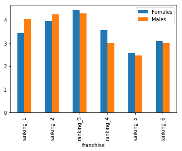

```python
# Analysis 3C: Part 1
# Dividing the data into male and female respondents

males = star_wars[star_wars["Gender"] == "Male"]
females = star_wars[star_wars["Gender"] == "Female"]

# Finding the mean ranking per film
mean_ranking_males = males[males.columns[9:15]].mean().tolist()
mean_ranking_females = females[females.columns[9:15]].mean().tolist()

# Preparation for grouped bar plots
new_column_names = ["franchise", "Males", "Females"]
bundled_data_list = [new_names_ranking, mean_ranking_males, mean_ranking_females]

bygender_ranking_dataframe = df_for_group_plot(bundled_data_list, new_column_names)
bygender_ranking_dataframe.plot(x = "franchise", kind = "bar")
```

Exploring by gender, the results are still consistent with other findings - Empire Strikes Back is the preferred franchise while newer franchises are less popular.

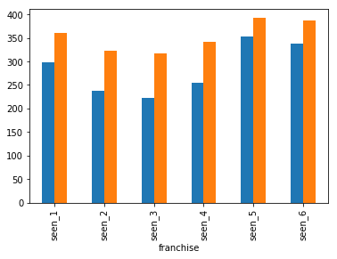

```python
# Analysis 3C: Part 2

# Finding the number of viewers per franchise
total_viewers_males = males[males.columns[3:9]].sum().tolist()
total_viewers_females = females[females.columns[3:9]].sum().tolist()

# Preparation for grouped bar plots
bundled_data_list = [new_names_seen, total_viewers_males, total_viewers_females]

bygender_viewers_dataframe = df_for_group_plot(bundled_data_list, new_column_names)
bygender_viewers_dataframe.plot(x = "franchise", kind = "bar", legend = False)
```

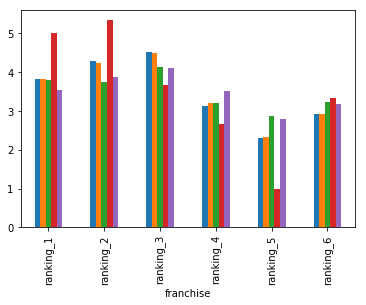

```python
# Analysis Next Step 1: Segmenting by Education

# Finding the unique responses for the column Education
education_list = star_wars["Education"].unique().tolist()
education_list.remove("Response")
education_list.remove(education_list[3])

# Segmenting the responses by education
high_school = star_wars[star_wars["Education"] == education_list[0]]
bachelor_degree = star_wars[star_wars["Education"] == education_list[1]]
some_college = star_wars[star_wars["Education"] == education_list[2]]
graduate_degree = star_wars[star_wars["Education"] == education_list[3]]
less_high_school = star_wars[star_wars["Education"] == education_list[4]]

# Getting the mean ranking for each education segment
def find_mean_rank(subset):
    mean_rank = subset[subset.columns[9:15]].mean().tolist()
    return (mean_rank)

mr_high_school = find_mean_rank(high_school)
mr_bachelor_degree = find_mean_rank(bachelor_degree)
mr_some_college = find_mean_rank(some_college)
mr_graduate_degree = find_mean_rank(graduate_degree)
mr_less_high_school = find_mean_rank(less_high_school)

# Preparation for grouped bar plots
new_column_names = ["franchise"] + education_list
bundled_data_list = [new_names_ranking, mr_high_school, mr_bachelor_degree, mr_some_college, mr_graduate_degree, mr_less_high_school]

byeducation_ranking_dataframe = df_for_group_plot(bundled_data_list, new_column_names)
byeducation_ranking_dataframe.plot(x = "franchise", kind = "bar", legend = False)
```

The color codes for the plots are:

Blue: Bachelor Degree

Orange: Graduate Degree

Green : High School Degree

Red: Less than high school degree

Violet: Some college or associate degree

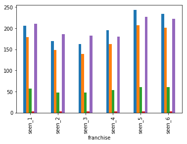

```python
# Analysis Next Step 1 - continuation

# Getting the number of viewers for each education segment

def find_total_viewers(subset):
    total_viewers = subset[subset.columns[3:9]].sum().tolist()
    return (total_viewers)

tv_high_school = find_total_viewers(high_school)
tv_bachelor_degree = find_total_viewers(bachelor_degree)
tv_some_college = find_total_viewers(some_college)
tv_graduate_degree = find_total_viewers(graduate_degree)
tv_less_high_school = find_total_viewers(less_high_school)

# Preparation for grouped bar plots
bundled_data_list = [new_names_seen, tv_high_school, tv_bachelor_degree, tv_some_college, tv_graduate_degree, tv_less_high_school]

byeducation_viewers_dataframe = df_for_group_plot(bundled_data_list, new_column_names)
byeducation_viewers_dataframe.plot(x = "franchise", kind = "bar", legend = False)
```

The color codes for the plots are:

Blue: Bachelor Degree

Orange: Graduate Degree

Green : High School Degree

Red: Less than high school degree

Violet: Some college or associate degree

The greatest number of viewers come from the educational segments with Bachelor Degrees, Graduate Degrees and some college or associate degrees. There are fewer viewers coming from the high school educational segments. Even less viewers are seen for less than high school degree.

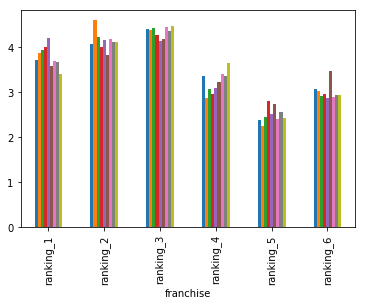

```python
# Analysis Next Step 2: Segmenting by Location

# Finding the unique responses for the column Location (Census Region)

location_list = star_wars["Location (Census Region)"].unique().tolist()
location_list.remove("Response")
location_list.remove(location_list[6])

# Segmenting the response by location

south_atlantic = star_wars[star_wars["Location (Census Region)"] == location_list[0]]
west_south_central = star_wars[star_wars["Location (Census Region)"] == location_list[1]]
west_north_central = star_wars[star_wars["Location (Census Region)"] == location_list[2]]
middle_atlantic = star_wars[star_wars["Location (Census Region)"] == location_list[3]]
east_north_central = star_wars[star_wars["Location (Census Region)"] == location_list[4]]
pacific = star_wars[star_wars["Location (Census Region)"] == location_list[5]]
mountain = star_wars[star_wars["Location (Census Region)"] == location_list[6]]
new_england = star_wars[star_wars["Location (Census Region)"] == location_list[7]]
east_south_central = star_wars[star_wars["Location (Census Region)"] == location_list[8]]

# Getting the mean ranking for each location segment
mr_south_atlantic = find_mean_rank(south_atlantic)
mr_west_south_central = find_mean_rank(west_south_central)
mr_west_north_central = find_mean_rank(west_north_central)
mr_middle_atlantic = find_mean_rank(middle_atlantic)
mr_east_north_central = find_mean_rank(east_north_central)
mr_pacific = find_mean_rank(pacific)
mr_mountain = find_mean_rank(mountain)
mr_new_england = find_mean_rank(new_england)
mr_east_south_central = find_mean_rank(east_south_central)

# Preparation for grouped bar plots
new_column_names = ["franchise"] + location_list
bundled_data_list = [new_names_ranking, mr_south_atlantic, mr_west_south_central, mr_west_north_central, mr_middle_atlantic, mr_east_north_central, mr_pacific, mr_mountain, mr_new_england, mr_east_south_central]

bylocation_ranking_dataframe = df_for_group_plot(bundled_data_list, new_column_names)
bylocation_ranking_dataframe.plot(x = "franchise", kind = "bar", legend = False)
```

The color codes for the plots are:

Blue: East North Central

Orange: East South Central

Green : Middle Atlantic

Red: Mountain

Violet: New England

Brown: Pacific

Pink: South Atlantic

Gray: West North Central

Light Green: West South Central

Consistent with previous observations, The Empire Strikes Back is the more popular among the franchises.

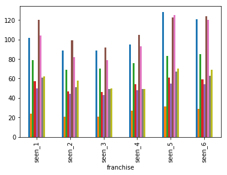

```python
# Analysis Next Step 2 - continuation

# Getting the number of viewers per location segment

tv_south_atlantic = find_total_viewers(south_atlantic)
tv_west_south_central = find_total_viewers(west_south_central)
tv_west_north_central = find_total_viewers(west_north_central)
tv_middle_atlantic = find_total_viewers(middle_atlantic)
tv_east_north_central = find_total_viewers(east_north_central)
tv_pacific = find_total_viewers(pacific)
tv_mountain = find_total_viewers(mountain)
tv_new_england = find_total_viewers(new_england)
tv_east_south_central = find_total_viewers(east_south_central)

# Preparation for Grouped Bar Plots
bundled_data_list = [new_names_seen, tv_south_atlantic, tv_west_south_central, tv_west_north_central, tv_middle_atlantic, tv_east_north_central, tv_pacific, tv_mountain, tv_new_england, tv_east_south_central]
bylocation_viewers_dataframe = df_for_group_plot(bundled_data_list, new_column_names)

bylocation_viewers_dataframe.plot(x = "franchise", kind = "bar", legend = False)
```

The color codes for the plots are:

Blue: East North Central

Orange: East South Central

Green : Middle Atlantic

Red: Mountain

Violet: New England

Brown: Pacific

Pink: South Atlantic

Gray: West North Central

Light Green: West South Central

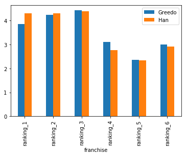

```python
# Analysis Next Step 3: Segmenting by the column
# Which character shot first?

# Finding the unique responses
character = star_wars["Which character shot first?"].unique().tolist()
character.remove("Response")
character.remove("I don't understand this question")
character.remove(character[0])

# Segmenting the response
greedo = star_wars[star_wars["Which character shot first?"] == "Greedo"]
han = star_wars[star_wars["Which character shot first?"] == "Han"]

# Getting the mean ranking
mr_greedo = find_mean_rank(greedo)
mr_han = find_mean_rank(han)

# Preparation for grouped bar plots
new_column_names = ["franchise"] + character
bundled_data_list = [new_names_ranking, mr_greedo, mr_han]
bycharacter_ranking_dataframe = df_for_group_plot(bundled_data_list, new_column_names)

bycharacter_ranking_dataframe.plot(x = "franchise", kind = "bar")
```

The question "Which character shot first?" is a Star Wars fan debate on a particular scene between Han Solo and Greedo in the Star Wars franchise A New Hope. Some say that Greedo shot first, while others say that Han Solo shot first.

Segmenting by these two characters still shows that The Empire Strikes Back is still the most popular franchise among the six. Once more, the older franchises are more popular than the newer franchises. Greedo defenders show the same trend in the ranking for the newer franchise while Han Solo defenders show no particular preference among the newer franchise.

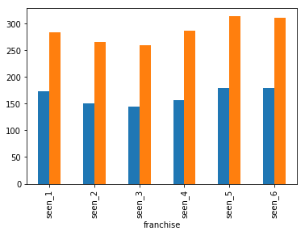

```python
# Analysis Next Step 3 - continuation

# Getting the number of viewers
tv_greedo = find_total_viewers(greedo)
tv_han = find_total_viewers(han)

# Preparation for Grouped Bar Plots
bundled_data_list = [new_names_seen, tv_greedo, tv_han]
bycharacter_viewers_dataframe = df_for_group_plot(bundled_data_list, new_column_names)

bycharacter_viewers_dataframe.plot(x = "franchise", kind = "bar", legend = False)
```

The color codes for the plots are:

Blue: Greedo defenders

Orange: Han Solo defenders

It is interesting to note that there is considerably a larger number of viewers for Han Solo defenders than Greedo defenders.

```python
# Data Cleaning Next Step - Clean Columns 15 to 29

# Renaming Columns
old_column_names = star_wars.columns[15:29].tolist()
character_names = ["Han Solo", "Luke Skywalker", "Princess Leia Organa", "Anakin Skywalker", "Obi Wan Kenobi", "Emperor Palpatine", "Darth Vader", "Lando Calrissian", "Boba Fett", "C-3P0", "R2 D2", "Jar Jar Binks", "Padme Amidala", "Yoda"]

rename_dictionary = {}

for i in range(0, len(old_column_names)):
    rename_dictionary[old_column_names[i]] = character_names[i]

star_wars = star_wars.rename(columns = rename_dictionary)

# Creating the numerical equivalent dictionary for the character ratings
old_rating_list = star_wars[star_wars.columns[15]].unique().tolist()
old_rating_list.remove("Han Solo")
old_rating_list.remove(old_rating_list[1])

new_rating_list = [1, 2, 3, 4, 5, 6]

replacement_dictionary = {}
for i in range(0, len(old_rating_list)):
    replacement_dictionary[old_rating_list[i]] = new_rating_list[i]

for character in character_names:
    replacement_dictionary[character] = None

replacement_dictionary["nan"] = None

for i in range(15, 29):
    star_wars[star_wars.columns[i]] = star_wars[star_wars.columns[i]].map(replacement_dictionary)

star_wars.head()
```

|  | RespondentID | Have you seen any of the 6 films in the Star Wars franchise? | Do you consider yourself to be a fan of the Star Wars film franchise? | seen_1 | seen_2 | seen_3 | seen_4 | seen_5 | seen_6 | ranking_1 | ... | Yoda | Which character shot first? | Are you familiar with the Expanded Universe? | Do you consider yourself to be a fan of the Expanded Universe?æ | Do you consider yourself to be a fan of the Star Trek franchise? | Gender | Age | Household Income | Education | Location (Census Region) |
| --- | --- | --- | --- | --- | --- | --- | --- | --- | --- | --- | --- | --- | --- | --- | --- | --- | --- | --- | --- | --- | --- |
| 0 | NaN | NaN | NaN | True | True | True | True | True | True | NaN | ... | NaN | Response | Response | Response | Response | Response | Response | Response | Response | Response |
| 1 | 3.292880e+09 | True | True | True | True | True | True | True | True | 3.0 | ... | 1.0 | I don't understand this question | Yes | No | No | Male | 18-29 | NaN | High school degree | South Atlantic |
| 2 | 3.292880e+09 | False | NaN | NaN | NaN | NaN | NaN | NaN | NaN | NaN | ... | NaN | NaN | NaN | NaN | Yes | Male | 18-29 | $0 - $24,999 | Bachelor degree | West South Central |
| 3 | 3.292765e+09 | True | False | True | True | True | NaN | NaN | NaN | 1.0 | ... | 5.0 | I don't understand this question | No | NaN | No | Male | 18-29 | $0 - $24,999 | High school degree | West North Central |
| 4 | 3.292763e+09 | True | True | True | True | True | True | True | True | 5.0 | ... | 1.0 | I don't understand this question | No | NaN | Yes | Male | 18-29 | $100,000 - $149,999 | Some college or Associate degree | West North Central |

5 rows × 38 columns

[figure not shown]

```python
# Analysis Next Step 4 - Finding the character most liked by the respondents and the character most disliked by the respondents

# Finding the mean rating per character
percharacter_mean_rating = star_wars[star_wars.columns[15:29]].mean()
percharacter_mean_rating.plot(kind = "bar")
```

The most popular characters are Han Solo and Yoda. Others following Han Solo and Yoda are: Luke Skywalker, Princess Leia, Obi Wan, and R2-D2.

The least liked character is Jar Jar Binks, followed by Emperor Palpatine.

[figure not shown]

```python
# Analysis Next Step 5: Finding the most controversial character.

# Finding the most controversial character in a positive sense (most favorable)
most_favorable_dictionary = {}

for i in range(15,29):
    most_favorable_dictionary[character_names[i-15]] = star_wars[star_wars.columns[i]] == 1

most_favorable_df = pd.DataFrame(most_favorable_dictionary)
most_favorable = most_favorable_df.sum()

most_favorable.plot(kind = "bar")
```

[figure not shown]

```python
# Analysis Next Step 5 - continuation

# Finding the most controversial character in a negative sense (least favorable character)
least_favorable_dictionary = {}

for i in range(15, 29):
    least_favorable_dictionary[character_names[i-15]] = star_wars[star_wars.columns[i]] == 6

least_favorable_df = pd.DataFrame(least_favorable_dictionary)
least_favorable = least_favorable_df.sum()

least_favorable.plot(kind = "bar")
```

Not surprisingly, the most controversial character in a negative sense (least favored) is Jar Jar Binks.